# Homework 05

Set a random seed before each simulation question and report it. You may use standard packages unless a question asks you to write the calculation yourself. Use equal neighbor weights throughout. Here $p$ counts the covariates used to measure distance; do not add an intercept column to a KNN predictor matrix. R and Python use different random-number generators, so their exact simulation results need not agree.

## Question 1: Estimate the bias and variance of KNN

In our previous homework, we used repeated simulations to study the behavior of linear regression estimators. We will now use the same idea for KNN. Consider the regression model

$$Y_i=f(\mathbf X_i)+\epsilon_i,
\qquad
f(\mathbf x)=0.5x_1+\sin(x_2)-0.3x_3^2,$$

where the three covariates are independent standard normal variables and $\epsilon_i\sim\mathcal N(0,0.1^2)$ independently of the covariates and other observations. Generate $n=400$ training observations. Our goal is to estimate the mean response at

$$\mathbf x_0=(0.5,0.7,1)^{\mathsf T}.$$

Use Euclidean distance and consider $k=1,3,5,\ldots,29$.

1. Calculate $f(\mathbf x_0)$. Generate one training dataset and obtain the KNN prediction at $\mathbf x_0$ for each value of $k$.

### Solution

**Show the workflow**

```python
import numpy as np
import pandas as pd
import matplotlib.pyplot as plt

# Set random seed for reproducibility
rng = np.random.default_rng(432)

# Parameters
n = 400
R = 200
ks = np.arange(1, 30, 2)  # k = 1, 3, 5, ..., 29

# Target prediction point
x0 = np.array([0.5, 0.7, 1.0])

# True regression function
def f(X):
    return (
        0.5 * X[:, 0]
        + np.sin(X[:, 1])
        - 0.3 * X[:, 2]**2
    )

# Calculate true mean response at x0
f0 = 0.5 * x0[0] + np.sin(x0[1]) - 0.3 * x0[2]**2

print(f"True mean response: {f0:.6f}")

def generate_and_predict():
    # Generate 400 observations with 3 independent N(0,1) predictors
    X = rng.normal(0, 1, size=(n, 3))

    # Generate responses with independent Gaussian errors
    y = f(X) + rng.normal(0, 0.1, size=n)

    # Calculate Euclidean distances from each observation to x0
    distances = np.linalg.norm(X - x0, axis=1)

    # Sort responses according to distance
    nearest_indices = np.argsort(distances)
    y_sorted = y[nearest_indices]

    # Calculate KNN predictions for all k
    predictions = []

    for k in ks:
        prediction = np.mean(y_sorted[:k])
        predictions.append(prediction)

    return np.array(predictions)


# Generate one training dataset
pred_a = generate_and_predict()

# Display predictions
results_a = pd.DataFrame({
    "k": ks,
    "KNN Prediction": pred_a
})

print(results_a.to_string(index=False))
```

```
True mean response: 0.594218
 k  KNN Prediction
 1        0.665669
 3        0.620677
 5        0.516720
 7        0.474724
 9        0.413956
11        0.401979
13        0.412739
15        0.355235
17        0.372738
19        0.377504
21        0.415738
23        0.438733
25        0.459468
27        0.426784
29        0.441876
```

2. Independently repeat the generation of the training covariates and responses 200 times. Within each repetition, use the same training data for every value of $k$. Store the predictions in a matrix with 200 rows and one column for each value of $k$. Use this matrix to estimate the bias, variance, and mean squared error of the estimated mean response. Use divisor 200 when calculating the empirical variance, and verify numerically that

$$\text{mean squared error}
=\text{squared bias}+\text{variance}.$$

Plot squared bias, variance, and mean squared error against $k$ in one figure. Explain the pattern and compare it with the bias-variance trade-off for ridge regression or lasso.

### Solution

**Show the workflow**

```
Prediction matrix shape: (200, 15)
 k      Bias  Squared Bias  Variance      MSE
 1 -0.044563      0.001986  0.035116 0.037101
 3 -0.036807      0.001355  0.019427 0.020782
 5 -0.044245      0.001958  0.015023 0.016981
 7 -0.053660      0.002879  0.011978 0.014857
 9 -0.062091      0.003855  0.010884 0.014739
11 -0.064524      0.004163  0.009790 0.013953
13 -0.067179      0.004513  0.009811 0.014325
15 -0.071749      0.005148  0.008756 0.013904
17 -0.077383      0.005988  0.008074 0.014062
19 -0.085891      0.007377  0.007683 0.015060
21 -0.090070      0.008113  0.007792 0.015904
23 -0.097381      0.009483  0.007087 0.016570
25 -0.104147      0.010847  0.007195 0.018041
```

[output cut: 19 more lines]

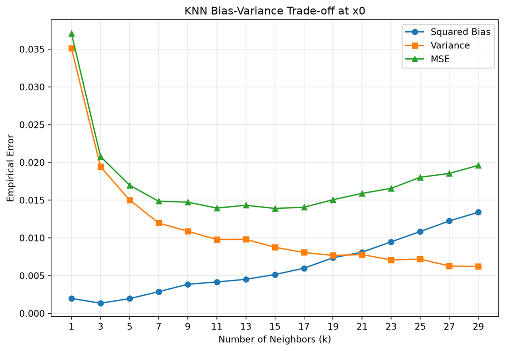

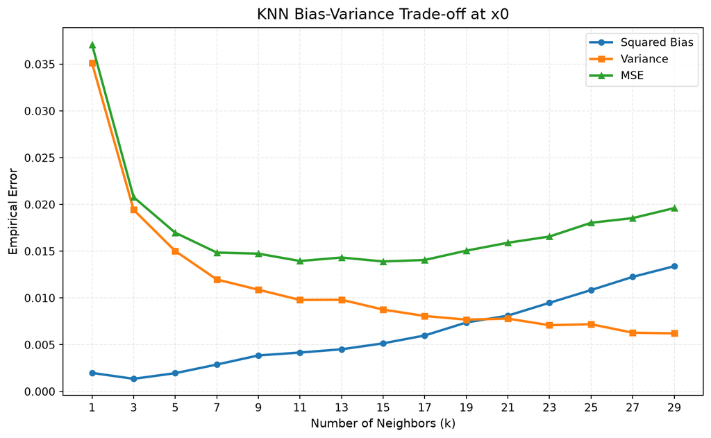

```python
# Store predictions in a 200 x 15 matrix
predictions = np.zeros((R, len(ks)))

for r in range(R):
    predictions[r, :] = generate_and_predict()

print("Prediction matrix shape:", predictions.shape)

# Mean prediction across 200 simulations
mean_pred = np.mean(predictions, axis=0)

# Empirical bias
bias = mean_pred - f0

# Squared bias
squared_bias = bias**2

# Empirical variance (divisor = 200)
variance = np.mean(
    (predictions - mean_pred)**2,
    axis=0
)

# Empirical mean squared error
mse = np.mean(
    (predictions - f0)**2,
    axis=0
)

# Display results
results_b = pd.DataFrame({
    "k": ks,
    "Bias": bias,
    "Squared Bias": squared_bias,
    "Variance": variance,
    "MSE": mse
})

print(results_b.round(6).to_string(index=False))

# Calculate MSE using bias-variance decomposition
mse_decomposition = squared_bias + variance

# Calculate numerical differences
difference = mse - mse_decomposition

verification = pd.DataFrame({
    "k": ks,
    "Direct MSE": mse,
    "Bias² + Variance": mse_decomposition,
    "Difference": difference
})

print(verification.to_string(index=False))

# Check numerical equality
print(
    "Decomposition verified:",
    np.allclose(mse, mse_decomposition)
)

# Original version kept for comparison
plt.figure(figsize=(9, 6))

plt.plot(
    ks, squared_bias,
    marker="o",
    label="Squared Bias"
)

plt.plot(
    ks, variance,
    marker="s",
    label="Variance"
)

plt.plot(
    ks, mse,
    marker="^",
    label="MSE"
)

plt.xlabel("Number of Neighbors (k)")
plt.ylabel("Empirical Error")
plt.title("KNN Bias-Variance Trade-off at x0")

plt.xticks(ks)
plt.legend()
plt.grid(alpha=0.3)

# Revised version using the stat432-plot-formatting skill
# This keeps the same data and statistical results while improving readability.
fig, ax = plt.subplots(figsize=(9, 5.5), constrained_layout=True)

colors = {
    "Squared Bias": "#1f77b4",
    "Variance": "#ff7f0e",
    "MSE": "#2ca02c"
}

ax.plot(
    ks, squared_bias,
    color=colors["Squared Bias"],
    marker="o",
    linewidth=2.2,
    markersize=5,
    label="Squared Bias"
)

ax.plot(
    ks, variance,
    color=colors["Variance"],
    marker="s",
    linewidth=2.2,
    markersize=5,
    label="Variance"
)

ax.plot(
    ks, mse,
    color=colors["MSE"],
    marker="^",
    linewidth=2.2,
    markersize=5,
    label="MSE"
)

ax.set_xlabel("Number of Neighbors (k)", fontsize=11)
ax.set_ylabel("Empirical Error", fontsize=11)
ax.set_title("KNN Bias-Variance Trade-off at x0", fontsize=14, pad=8)
ax.set_xticks(np.arange(1, 30, 2))
ax.tick_params(axis="both", labelsize=10)
ax.grid(alpha=0.25, linestyle="--")
ax.legend(loc="upper right", frameon=True, facecolor="white", edgecolor="0.85", fontsize=10)
```

We independently generate 200 training datasets and obtain KNN predictions for each value of $k$. Within each repetition, the same dataset is used for all values of $k$. We estimate the bias, variance, and MSE as follows:

$$\widehat{\operatorname{Bias}}_k
= \overline{\hat{f}}_k(x_0) - f(x_0),$$

$$\widehat{\operatorname{Var}}_k
= \frac{1}{200}\sum_{r=1}^{200}
\left(\hat{f}_{r,k}(x_0)-\overline{\hat{f}}_k(x_0)\right)^2,$$

$$\widehat{\operatorname{MSE}}_k
= \frac{1}{200}\sum_{r=1}^{200}
\left(\hat{f}_{r,k}(x_0)-f(x_0)\right)^2,$$

where $\overline{\hat{f}}_k(x_0)$ is the average prediction across the 200 repetitions.

Using a divisor of 200, we numerically verify that

$$\widehat{\operatorname{MSE}}_k
=
\widehat{\operatorname{Bias}}_k^2
+
\widehat{\operatorname{Var}}_k.$$

The maximum numerical difference is approximately $5.38 \times 10^{-17}$.

As $k$ increases, variance generally decreases because predictions are averaged over more neighbors, while squared bias tends to increase as more distant observations are included. Consequently, MSE initially decreases and then increases, illustrating the bias-variance trade-off. In our simulation, $k=15$ gives the lowest empirical MSE.

This trade-off is similar to ridge regression and lasso, where increasing $\lambda$ typically reduces variance but increases bias. The difference is that KNN controls model complexity through the number of neighbors, while ridge and lasso use regularization.

## Question 2: Compare KNN with lasso

Use the response model from Question 1, including the noise standard deviation $0.1$, but generate $p=30$ covariates. The response still depends only on the first three. Consider these two settings:

- **Setting 1:** all 30 covariates are independent standard normal variables.
- **Setting 2:** the covariates have a multivariate normal distribution with mean zero and covariance matrix $\boldsymbol\Sigma$, where

  $$\Sigma_{jj}=1,
  \qquad
  \Sigma_{jl}=0.8\quad\text{for }j\ne l.$$

In each setting, generate 400 training observations and 1,000 independent test observations. Fit 5NN using Euclidean distance on the supplied covariate scale. All covariates already have population variance one.

For lasso, use a linear model containing the 30 covariates and a separately fitted, unpenalized intercept. Follow the Week 4 objective,

$$L_\lambda(\boldsymbol\beta)
=\frac{1}{2n}\left\lVert
\widetilde{\mathbf y}-\mathbf X\boldsymbol\beta
\right\rVert_2^2
+\lambda\lVert\boldsymbol\beta\rVert_1,$$

where $\mathbf X\in\mathbb R^{n\times30}$ contains the centered and standardized covariates and $\widetilde{\mathbf y}$ is the centered training response. Select the penalty by ten-fold cross-validation over 41 logarithmically spaced values from $10^{-4}$ to $1$. Estimate all means and scales using only the training portion of each fold, with divisor equal to that portion’s sample size. After selecting the penalty, refit on all training observations and apply the fitted transformations unchanged to the test observations. Do not add nonlinear terms to the lasso model.

1. Fit both methods in each setting. Use the same training and test data for the two methods within a setting. Report their test MSE values in one table, together with the selected lasso penalty and the number of nonzero lasso slopes. You only need to generate one dataset for each setting; repeated simulations are not required.

### Solution

**Show the workflow**

```python
import numpy as np
import pandas as pd
from sklearn.neighbors import KNeighborsRegressor
from sklearn.linear_model import Lasso
from sklearn.model_selection import GridSearchCV, KFold
from sklearn.preprocessing import StandardScaler
from sklearn.pipeline import Pipeline
from sklearn.metrics import mean_squared_error

# Parameters
rng = np.random.default_rng(432)
n_train, n_test, p = 400, 1000, 30
lambdas = np.logspace(-4, 0, 41)

# Generate training and test datasets
def generate_data(Sigma):
    X_train = rng.multivariate_normal(np.zeros(p), Sigma, n_train)
    X_test = rng.multivariate_normal(np.zeros(p), Sigma, n_test)

    def f(X):
        return (
            0.5 * X[:, 0]
            + np.sin(X[:, 1])
            - 0.3 * X[:, 2]**2
        )

    y_train = f(X_train) + rng.normal(0, 0.1, n_train)
    y_test = f(X_test) + rng.normal(0, 0.1, n_test)

    return X_train, X_test, y_train, y_test


def compare_models(Sigma):
    X_train, X_test, y_train, y_test = generate_data(Sigma)

    # 5NN: Use all 30 original predictors
    knn = KNeighborsRegressor(
        n_neighbors=5,
        metric="euclidean"
    )

    knn.fit(X_train, y_train)
    knn_mse = mean_squared_error(
        y_test, knn.predict(X_test)
    )

    # Lasso: Standardize predictors within each CV fold
    lasso_pipeline = Pipeline([
        ("scaler", StandardScaler()),
        ("lasso", Lasso(
            fit_intercept=True,
            max_iter=100000,
            tol=1e-8
        ))
    ])

    cv = KFold(
        n_splits=10,
        shuffle=True,
        random_state=432
    )

    search = GridSearchCV(
        lasso_pipeline,
        param_grid={"lasso__alpha": lambdas},
        scoring="neg_mean_squared_error",
        cv=cv,
        refit=True
    )

    search.fit(X_train, y_train)

    # Evaluate the refitted lasso model
    lasso_mse = mean_squared_error(
        y_test, search.predict(X_test)
    )

    # Selected penalty and number of nonzero slopes
    best_lambda = search.best_params_["lasso__alpha"]
    coefficients = search.best_estimator_.named_steps["lasso"].coef_
    nonzero = np.count_nonzero(coefficients)

    return knn_mse, lasso_mse, best_lambda, nonzero


# Setting 1: Independent predictors
Sigma1 = np.eye(p)

# Setting 2: Pairwise correlation of 0.8
Sigma2 = 0.2 * np.eye(p) + 0.8 * np.ones((p, p))

result1 = compare_models(Sigma1)
result2 = compare_models(Sigma2)

# Report results in one table
results = pd.DataFrame(
    [result1, result2],
    index=["Independent", "Correlated"],
    columns=[
        "5NN Test MSE",
        "Lasso Test MSE",
        "Selected Lambda",
        "Nonzero Lasso Slopes"
    ]
)

print(results.round(6).to_string())
```

```
             5NN Test MSE  Lasso Test MSE  Selected Lambda  Nonzero Lasso Slopes
Independent      0.559409        0.234448         0.039811                     4
Correlated       0.180818        0.271788         0.012589                     9
```

2. Compare the results between the two settings. Explain how correlation can change the usefulness of Euclidean neighborhoods, and why lasso does not use all covariates in the same way as KNN.

### Solution

In Setting 1, lasso has a lower test MSE (0.234448) than KNN (0.559409). Since KNN uses all 30 predictors to calculate Euclidean distances, the 27 irrelevant predictors make it harder to identify meaningful neighbors.

In Setting 2, KNN’s test MSE decreases to 0.180818. The strong correlations reduce the effective dimensionality of the data, making Euclidean neighborhoods more informative in this simulation.

Unlike KNN, lasso uses an L1 penalty to shrink coefficients and perform variable selection. However, highly correlated predictors can make variable selection less stable. In our simulation, the number of nonzero lasso slopes increases from 4 to 9.

3. The response model contains $\sin(X_2)$ and $X_3^2$, but the lasso fit uses only linear terms. Explain how this difference affects the comparison. Would the results justify a general claim that correlation always helps KNN, or that one method is always better? Explain why.

### Solution

The true response contains nonlinear terms, $\sin(X_2)$ and $X_3^2$, while lasso uses only linear predictors. Therefore, lasso cannot fully represent the true relationship, introducing model bias.

KNN can capture nonlinear relationships without specifying their functional forms, but its performance may suffer from the curse of dimensionality.

In our simulation, lasso performs better with independent predictors, while KNN performs better with correlated predictors. However, these results do not imply that correlation always improves KNN or that one method is always better. Performance depends on the data distribution, dimensionality, sample size, and underlying response function.

## Question 3: Observed dimension and latent dimension

The lecture’s handwritten digit example shows that KNN can work with many measured covariates. We will use a simulation to investigate why the structure of those covariates matters.

Let $p=100$ be the number of observed covariates and let $m$ be the number of latent variables. For each observation, generate

$$\mathbf X_i=\mathbf A\mathbf Z_i+\boldsymbol\eta_i,
\qquad
Y_i=Z_{i1}+Z_{i2}+\epsilon_i,$$

where $\mathbf A\in\mathbb R^{100\times m}$ has independent entries from Uniform$[-2,2]$. The entries of $\mathbf Z_i\in\mathbb R^m$ and $\boldsymbol\eta_i\in\mathbb R^{100}$, and the scalar $\epsilon_i$, are independent standard normal variables, also independent of $\mathbf A$. Generate $\mathbf A$ once and use it for all training and test observations in that dataset.

Compare $m=3$ and $m=30$. In each setting, generate 200 training observations and 200 independent test observations. Fit KNN using only the 100 observed covariates in $\mathbf X$, with Euclidean distance on their generated scale. The latent variables in $\mathbf Z$ are used to generate the data but are not available to the fitted model. Consider $k=2,10,18,\ldots,82$.

1. Generate one dataset for each value of $m$. Fit KNN for every value of $k$ and calculate test MSE. Within a setting, use the same training and test observations for all values of $k$.

### Solution

**Show the workflow**

```python
import numpy as np
import pandas as pd
import matplotlib.pyplot as plt
from sklearn.neighbors import NearestNeighbors
from sklearn.metrics import mean_squared_error

# Set random seed
rng = np.random.default_rng(432)

# Parameters
p = 100
n_train = 200
n_test = 200
ks = np.arange(2, 83, 8)  # 2, 10, 18, ..., 82

# Generate one dataset for a given latent dimension
def generate_data(m):
    # Generate A once for both training and test data
    A = rng.uniform(-2, 2, size=(p, m))

    # Generate independent latent variables
    Z_train = rng.normal(size=(n_train, m))
    Z_test = rng.normal(size=(n_test, m))

    # Generate measurement noise
    eta_train = rng.normal(size=(n_train, p))
    eta_test = rng.normal(size=(n_test, p))

    # Generate observed predictors: X = AZ + eta
    X_train = Z_train @ A.T + eta_train
    X_test = Z_test @ A.T + eta_test

    # Generate responses: Y = Z1 + Z2 + epsilon
    y_train = (
        Z_train[:, 0] + Z_train[:, 1]
        + rng.normal(size=n_train)
    )

    y_test = (
        Z_test[:, 0] + Z_test[:, 1]
        + rng.normal(size=n_test)
    )

    return X_train, X_test, y_train, y_test


# Calculate test MSE for all k using the same dataset
def evaluate_knn(X_train, X_test, y_train, y_test):
    # Find the 82 nearest neighbors of each test observation
    neighbors = NearestNeighbors(
        n_neighbors=max(ks),
        metric="euclidean"
    )
    neighbors.fit(X_train)

    indices = neighbors.kneighbors(
        X_test, return_distance=False
    )

    # Responses of the nearest neighbors, ordered by distance
    neighbor_y = y_train[indices]

    # KNN prediction = average of the first k responses
    cumulative_y = np.cumsum(neighbor_y, axis=1)
    predictions = cumulative_y[:, ks - 1] / ks

    # Calculate test MSE for every k
    mse = np.mean(
        (predictions - y_test[:, None])**2,
        axis=0
    )

    return mse


# Generate one dataset for each setting
X_train_3, X_test_3, y_train_3, y_test_3 = generate_data(3)
X_train_30, X_test_30, y_train_30, y_test_30 = generate_data(30)

# Evaluate KNN
mse_3 = evaluate_knn(
    X_train_3, X_test_3, y_train_3, y_test_3
)

mse_30 = evaluate_knn(
    X_train_30, X_test_30, y_train_30, y_test_30
)

# Display results
results_a = pd.DataFrame({
    "k": ks,
    "Test MSE (m=3)": mse_3,
    "Test MSE (m=30)": mse_30
})

print(results_a.round(4).to_string(index=False))
```

```
 k  Test MSE (m=3)  Test MSE (m=30)
 2          1.7432           2.6605
10          1.3799           1.8878
18          1.3967           1.9090
26          1.4515           1.9701
34          1.5424           2.0516
42          1.5948           2.0559
50          1.6532           2.0776
58          1.7249           2.1289
66          1.7924           2.1382
74          1.8586           2.1738
82          1.9120           2.2268
```

2. Repeat the complete experiment 50 times, generating a new $\mathbf A$ and new observations in each repetition. Plot average test MSE against $k$, with one curve for each value of $m$. These curves compare the specified choices of $k$ in a controlled simulation; they are not a cross-validation procedure for selecting a final model.

### Solution

**Show the workflow**

```
 k  Average Test MSE (m=3)  Average Test MSE (m=30)
 2                  1.6884                   3.0220
10                  1.2962                   2.3217
18                  1.3254                   2.2952
26                  1.3681                   2.3262
34                  1.4244                   2.3606
42                  1.4837                   2.3981
50                  1.5424                   2.4279
58                  1.6030                   2.4615
66                  1.6651                   2.4938
74                  1.7261                   2.5259
82                  1.7893                   2.5558
```

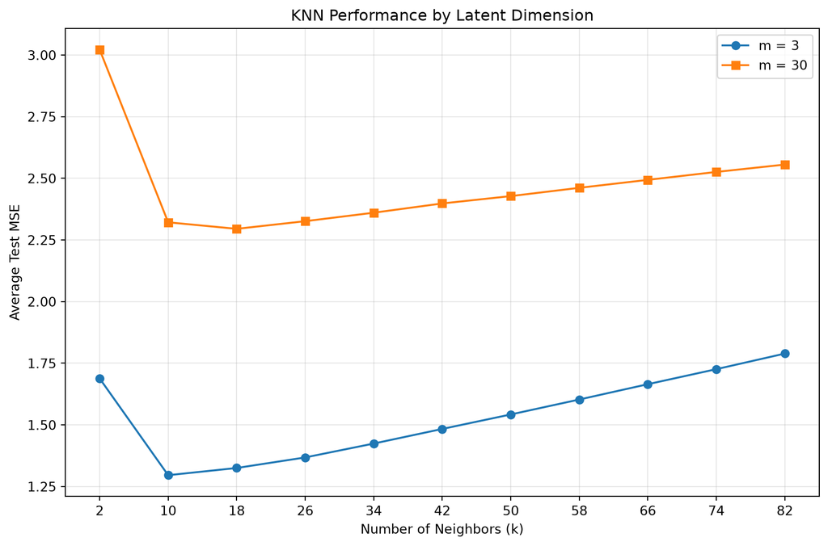

```python
# Repeat the complete experiment 50 times
R = 50

# Store MSE values for each repetition and each k
mse_results_3 = np.zeros((R, len(ks)))
mse_results_30 = np.zeros((R, len(ks)))

for r in range(R):
    # Setting 1: m = 3
    X_train, X_test, y_train, y_test = generate_data(3)

    mse_results_3[r, :] = evaluate_knn(
        X_train, X_test, y_train, y_test
    )

    # Setting 2: m = 30
    X_train, X_test, y_train, y_test = generate_data(30)

    mse_results_30[r, :] = evaluate_knn(
        X_train, X_test, y_train, y_test
    )

# Average test MSE across 50 repetitions
avg_mse_3 = np.mean(mse_results_3, axis=0)
avg_mse_30 = np.mean(mse_results_30, axis=0)

# Display results
results_b = pd.DataFrame({
    "k": ks,
    "Average Test MSE (m=3)": avg_mse_3,
    "Average Test MSE (m=30)": avg_mse_30
})

print(results_b.round(4).to_string(index=False))

# Plot average test MSE against k
plt.figure(figsize=(9, 6))

plt.plot(
    ks, avg_mse_3,
    marker="o",
    label="m = 3"
)

plt.plot(
    ks, avg_mse_30,
    marker="s",
    label="m = 30"
)

plt.xlabel("Number of Neighbors (k)")
plt.ylabel("Average Test MSE")
plt.title("KNN Performance by Latent Dimension")
plt.xticks(ks)
plt.legend()
plt.grid(alpha=0.3)

plt.tight_layout()
plt.show()
```

3. Both settings have 100 observed covariates, and the response depends on only two latent variables. Explain why their KNN performance can still differ. What role does the noise $\boldsymbol\eta_i$ play, and why are the observed data not confined exactly to an $m$-dimensional linear space?

### Solution

Although both settings have 100 observed predictors and the response depends on only two latent variables, their KNN performance differs because of the underlying latent dimension.

Our results show that $m=3$ consistently achieves a lower average test MSE than $m=30$. With fewer latent variables, Euclidean distance is more likely to reflect differences in the response-relevant variables. When $m=30$, the additional latent variables introduce variation unrelated to the response, making it harder for KNN to identify meaningful neighbors.

The measurement noise $\eta_i$ adds independent variation to all 100 observed predictors, further distorting Euclidean distances. Without this noise, the observations would lie in the column space of $A$, which has dimension at most $m$. Because of the measurement noise, the observed data are not confined exactly to an $m$-dimensional linear space.

## Question 4: Classify handwritten digits

Use `zip.train` and `zip.test` from the R package `ElemStatLearn`, as in the lecture. The package has been retired from the active CRAN repository. If needed, install the [archived package](https://cran.r-project.org/src/contrib/Archive/ElemStatLearn/ElemStatLearn_2015.6.26.2.tar.gz) into your usual R library, then load the two datasets. Python users can use the course copies of the same [training data](https://teazrq.github.io/stat432rpy/data/knn/zip-train.csv.gz) and [test data](https://teazrq.github.io/stat432rpy/data/knn/zip-test.csv.gz). These compressed CSV files have no headers and are included in the homework ZIP under `data/knn`. Run the Python code from the folder containing `data`.

Each image has $16\times16=256$ pixel values. The first column is the digit label and the remaining columns are the pixel values. Use the first 1,000 rows of `zip.train` and the first 500 rows of `zip.test`. Use the original pixel values without standardization, and do not include the digit label in a distance calculation.

For a test image $\mathbf x_0$ and a training image $\mathbf x_i$, the two distances are

$$d_E(\mathbf x_0,\mathbf x_i)
=\sqrt{\sum_{j=1}^{256}(x_{0j}-x_{ij})^2},
\qquad
d_M(\mathbf x_0,\mathbf x_i)
=\sum_{j=1}^{256}|x_{0j}-x_{ij}|.$$

1. Write a 5NN classification function that allows either Euclidean or Manhattan distance. For each test image, calculate its distances to the training images directly, find the five nearest, and return the most frequent digit label. Break distance ties by the smaller training row number and voting ties by the smallest digit. Do not use a built-in distance or KNN function for this part.

### Solution

**Show the workflow**

```python
import numpy as np
import pandas as pd
from pathlib import Path

# Load the course datasets
train_path = Path("data/knn/zip-train.csv.gz")
test_path = Path("data/knn/zip-test.csv.gz")

train = pd.read_csv(train_path, header=None).iloc[:1000]
test = pd.read_csv(test_path, header=None).iloc[:500]

# First column: digit labels
y_train = train.iloc[:, 0].to_numpy(dtype=int)
y_test = test.iloc[:, 0].to_numpy(dtype=int)

# Remaining 256 columns: original pixel values
X_train = train.iloc[:, 1:].to_numpy(dtype=float)
X_test = test.iloc[:, 1:].to_numpy(dtype=float)

print("Training data:", X_train.shape)
print("Test data:", X_test.shape)


# Custom 5NN classification function
def predict_5nn(X_train, y_train, X_test, metric="euclidean"):

    predictions = np.zeros(len(X_test), dtype=int)
    train_rows = np.arange(len(X_train))

    for i, x0 in enumerate(X_test):

        # Calculate distances directly
        differences = X_train - x0

        if metric == "euclidean":
            distances = np.sqrt(
                np.sum(differences**2, axis=1)
            )

        elif metric == "manhattan":
            distances = np.sum(
                np.abs(differences), axis=1
            )

        else:
            raise ValueError(
                "Metric must be 'euclidean' or 'manhattan'."
            )

        # Sort by distance, breaking ties by training row
        sorted_indices = np.lexsort(
            (train_rows, distances)
        )

        # Select five nearest neighbors
        nearest_indices = sorted_indices[:5]
        nearest_labels = y_train[nearest_indices]

        # Majority vote; ties go to the smallest digit
        votes = np.bincount(
            nearest_labels, minlength=10
        )

        predictions[i] = np.argmax(votes)

    return predictions


# Predict test labels using both distances
pred_euclidean = predict_5nn(
    X_train, y_train, X_test,
    metric="euclidean"
)

pred_manhattan = predict_5nn(
    X_train, y_train, X_test,
    metric="manhattan"
)

print("Euclidean predictions:", pred_euclidean[:10])
print("Manhattan predictions:", pred_manhattan[:10])
```

```
Training data: (1000, 256)
Test data: (500, 256)
Euclidean predictions: [9 6 3 0 6 0 0 0 6 9]
Manhattan predictions: [9 6 3 0 6 0 0 0 6 9]
```

2. Apply the classifier to all 500 test images using each distance. For each fit, report the test classification error and a $10\times10$ confusion matrix, with rows representing predicted digits and columns representing true digits. Keep all digit labels from 0 through 9 in the matrix, including any with a zero count. Which digits are most often confused with one another?

### Solution

**Show the workflow**

```python
# Calculate test classification error
error_euclidean = np.mean(pred_euclidean != y_test)
error_manhattan = np.mean(pred_manhattan != y_test)

print(f"Euclidean Test Error: {error_euclidean:.4f}")
print(f"Manhattan Test Error: {error_manhattan:.4f}")


# Confusion matrix: rows = predicted, columns = true
def make_confusion_matrix(y_true, y_pred):

    matrix = np.zeros((10, 10), dtype=int)

    for true, pred in zip(y_true, y_pred):
        matrix[pred, true] += 1

    return pd.DataFrame(
        matrix,
        index=pd.Index(range(10), name="Predicted"),
        columns=pd.Index(range(10), name="True")
    )


cm_euclidean = make_confusion_matrix(
    y_test, pred_euclidean
)

cm_manhattan = make_confusion_matrix(
    y_test, pred_manhattan
)

print("\nEuclidean Confusion Matrix:")
print(cm_euclidean.to_string())

print("\nManhattan Confusion Matrix:")
print(cm_manhattan.to_string())


# Find the most frequently confused digit pair
def most_confused_pair(cm):

    pairs = []

    for a in range(10):
        for b in range(a + 1, 10):

            # Count mistakes in both directions
            count = cm.loc[a, b] + cm.loc[b, a]

            pairs.append((a, b, count))

    pairs.sort(key=lambda x: (-x[2], x[0], x[1]))

    return pairs[:5]


print("\nMost confused pairs (Euclidean):")
print(most_confused_pair(cm_euclidean))

print("\nMost confused pairs (Manhattan):")
print(most_confused_pair(cm_manhattan))
```

```
Euclidean Test Error: 0.1220
Manhattan Test Error: 0.1380

Euclidean Confusion Matrix:
True         0   1   2   3   4   5   6   7   8   9
Predicted
0          118   0   7   1   0   4   2   0   2   0
1            0  66   0   0   2   0   0   0   0   1
2            0   0  39   1   0   0   2   0   0   1
3            0   0   0  23   0   4   0   0   2   0
4            0   0   1   0  27   1   1   1   0   1
5            0   0   0   1   0  13   0   0   0   0
6            0   2   0   0   0   1  41   0   2   0
7            0   0   0   0   1   1   0  34   0   4
8            0   0   3   2   0   2   0   0  37   0
9            1   0   0   1   4   0   0   1   1  41

Manhattan Confusion Matrix:
True         0   1   2   3   4   5   6   7   8   9
Predicted
0          118   0   6   1   0   5   3   0   4   0
1            0  67   2   0   2   0   1   0   0   1
2            0   0  35   0   0   0   2   0   0   0
3            0   0   1  24   0   4   0   0   2   0
4            0   0   1   1  27   1   0   1   0   1
5            0   0   0   1   0  11   0   0   0   0
6            0   1   0   0   0   2  40   0   2   0
7            0   0   2   1   1   0   0  34   0   5
8            0   0   2   0   0   3   0   0  34   0
9            1   0   1   1   4   0   0   1   2  41

Most confused pairs (Euclidean):
[(0, 2, np.int64(7)), (3, 5, np.int64(5)), (4, 9, np.int64(5)), (7, 9, np.int64(5)), (0, 5, np.int64(4))]

Most confused pairs (Manhattan):
[(0, 2, np.int64(6)), (7, 9, np.int64(6)), (0, 5, np.int64(5)), (3, 5, np.int64(5)), (4, 9, np.int64(5))]
```

The test classification error is 0.122 (12.2%) using Euclidean distance and 0.138 (13.8%) using Manhattan distance.

For Euclidean distance, the most frequently confused digits are 0 and 2 (7 errors), followed by 3 and 5, 4 and 9, and 7 and 9 (5 errors each). For Manhattan distance, the most frequently confused pairs are 0 and 2 and 7 and 9 (6 errors each).

3. For Euclidean distance, display three incorrectly classified test images, together with their true and predicted labels. Comment on whether the mistakes are visually understandable. Compare the overall results of the two distance measures. Can they have similar total error while making mistakes on different images? Use your predictions to support your answer.

### Solution

**Show the workflow**

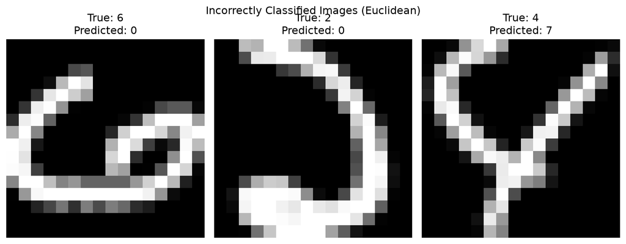

```
                  Category  Count
            Both incorrect     58
  Only Euclidean incorrect      3
  Only Manhattan incorrect     11
              Both correct    428
Different predicted labels     22

Images with different predictions:
 Test Image  True Label  Euclidean  Manhattan
         13           2          0          3
         33           5          5          0
         37           5          7          8
         64           2          2          7
        123           3          2          7
        155           8          8          9
```

[output cut: 47 more lines]

```python
import matplotlib.pyplot as plt

# Identify incorrectly classified images (Euclidean)
wrong_euclidean = np.where(
    pred_euclidean != y_test
)[0]

# Select the first three incorrectly classified images
selected = wrong_euclidean[:3]

# Display images
fig, axes = plt.subplots(1, 3, figsize=(10, 4))

for ax, idx in zip(axes, selected):

    image = X_test[idx].reshape(16, 16)

    ax.imshow(
        image,
        cmap="gray",
        interpolation="nearest"
    )

    ax.set_title(
        f"True: {y_test[idx]}\n"
        f"Predicted: {pred_euclidean[idx]}"
    )

    ax.axis("off")

plt.suptitle("Incorrectly Classified Images (Euclidean)")
plt.tight_layout()
plt.show()


# Identify errors made by each method
wrong_e = pred_euclidean != y_test
wrong_m = pred_manhattan != y_test

# Compare the errors
both_wrong = np.sum(wrong_e & wrong_m)

only_e_wrong = np.sum(wrong_e & ~wrong_m)

only_m_wrong = np.sum(~wrong_e & wrong_m)

both_correct = np.sum(~wrong_e & ~wrong_m)

# Number of images receiving different predictions
different_predictions = np.sum(
    pred_euclidean != pred_manhattan
)

comparison = pd.DataFrame({
    "Category": [
        "Both incorrect",
        "Only Euclidean incorrect",
        "Only Manhattan incorrect",
        "Both correct",
        "Different predicted labels"
    ],
    "Count": [
        both_wrong,
        only_e_wrong,
        only_m_wrong,
        both_correct,
        different_predictions
    ]
})

print(comparison.to_string(index=False))


# Show which test images have different predictions
different_indices = np.where(
    pred_euclidean != pred_manhattan
)[0]

prediction_comparison = pd.DataFrame({
    "Test Image": different_indices + 1,
    "True Label": y_test[different_indices],
    "Euclidean": pred_euclidean[different_indices],
    "Manhattan": pred_manhattan[different_indices]
})

print("\nImages with different predictions:")
print(prediction_comparison.to_string(index=False))


# Identify errors made by each method
wrong_e = pred_euclidean != y_test
wrong_m = pred_manhattan != y_test

# Compare the errors
both_wrong = np.sum(wrong_e & wrong_m)

only_e_wrong = np.sum(wrong_e & ~wrong_m)

only_m_wrong = np.sum(~wrong_e & wrong_m)

both_correct = np.sum(~wrong_e & ~wrong_m)

# Number of images receiving different predictions
different_predictions = np.sum(
    pred_euclidean != pred_manhattan
)

comparison = pd.DataFrame({
    "Category": [
        "Both incorrect",
        "Only Euclidean incorrect",
        "Only Manhattan incorrect",
        "Both correct",
        "Different predicted labels"
    ],
    "Count": [
        both_wrong,
        only_e_wrong,
        only_m_wrong,
        both_correct,
        different_predictions
    ]
})

print(comparison.to_string(index=False))


# Show which test images have different predictions
different_indices = np.where(
    pred_euclidean != pred_manhattan
)[0]

prediction_comparison = pd.DataFrame({
    "Test Image": different_indices + 1,
    "True Label": y_test[different_indices],
    "Euclidean": pred_euclidean[different_indices],
    "Manhattan": pred_manhattan[different_indices]
})

print("\nImages with different predictions:")
print(prediction_comparison.to_string(index=False))
```

The three misclassified images are visually understandable. The digit 6 is classified as 0 because of its rounded lower loop, while the digit 2 is classified as 0 because its curved shape resembles a poorly written 0. The digit 4 is classified as 7 because its upper strokes resemble a 7.

Euclidean distance achieves a slightly lower test error (12.2%) than Manhattan distance (13.8%). However, the two methods make different predictions on 22 test images. Both methods misclassify 58 images, while 3 are misclassified only by Euclidean distance and 11 only by Manhattan distance.

These results show that two distance measures can have similar overall classification errors while making mistakes on different images. This occurs because Euclidean and Manhattan distances measure pixel differences differently, which can lead to different nearest neighbors.

## Question 5: Create a plot-formatting skill

Create a short `SKILL.md` file for improving the formatting of STAT 432 homework plots. You may use AI to help write it.

1. Include a title, a description, and a few formatting rules. The description should limit the skill to STAT 432 homework plot improvements and require an explicit request to use it. Your rules should address margins, titles, axes, labels, colors, and sizes for plots produced in R or Python. Keep them portable: do not refer to specific homework questions.
2. Ask your agent to install the skill. Explicitly call it to improve the plot from Question 1, then compare the original and revised versions. Do you like the changes? You may revise the skill and test it a couple more times, or uninstall it if it remains unhelpful.

### Solution

I don’t really prefer the revised plot because I don’t see a significant improvement over the original. It also took several attempts to adjust the figure size and fix the clipping issues. Overall, I think the original plot was already clear and readable, and the additional changes were not worth the effort.

3. Append your final `SKILL.md` content to your submission and briefly explain your choices and experience.

### Solution

```markdown
---
name: stat432-plot-formatting
description: Use only when the user explicitly asks to improve the formatting of a STAT 432 homework plot. This skill is limited to STAT 432 homework plot improvements in R or Python and should not be used for unrelated plotting tasks.
---

# STAT 432 Plot Formatting

Improve the formatting of STAT 432 homework plots while preserving the underlying data, statistical meaning, and code structure.

When explicitly asked to use this skill:

1. Keep the plot readable and polished without changing the analysis itself.
2. Prefer clean, portable plotting defaults that work well in both R and Python.
3. Make targeted formatting improvements only where they help comprehension.

## Formatting rules

- Leave enough margin around the figure so titles, labels, tick marks, and legends are not clipped.
- Use a short, informative title that explains the main takeaway without being overly wordy.
- Label axes clearly, include units when relevant, and keep tick labels legible.
- Use a consistent axis scale and avoid unnecessary distortion of the visualized relationship.
- Prefer a simple, colorblind-friendly palette; use line styles or markers to distinguish multiple series when needed.
- Keep text large enough to read clearly in a rendered figure or PDF, with titles and labels set larger than default tick labels.
- Prefer legends inside the plotting area when sufficient space is available, and keep enough padding so labels remain readable and do not overlap the curves.
- Reserve space for legends so they do not overlap the curves or get clipped at the edge of a rendered Quarto figure; place legends inside the axes or just outside the plotting area when needed.
- Verify the rendered output after adjusting layout; do not rely only on the Python code when clipping or legend cutoffs are possible.
- Use a balanced figure size such as roughly 6 to 8 inches wide and 4 to 6 inches tall, adjusting for multiple panels or crowded plots.
- Maintain clear visual hierarchy: emphasize the main result, but keep grid lines, annotations, and legends subtle and not distracting.
- Preserve the original content and avoid changing the statistical conclusions, model choice, or plotted values.
- Apply these rules to existing R or Python plotting code without assuming a specific homework question or dataset.
```

I chose these formatting rules to improve readability while preserving the original statistical results. After encountering clipping issues during testing, I refined the skill to prioritize the rendered document layout rather than unnecessarily enlarging figures.